# Temperatura JP x CG

```r
climas = read_csv(here::here("data/clima_cg_jp-semanal.csv"), col_types = "cTdddddd")
```

## Temperatura

### Onde é mais quente?

Para determinar qual das duas cidades é mais quente, podemos utilizar diferentes formas de comparação. Aqui, escolhemos comparar as temperaturas médias pois o valor da temperatura máxima pode não ser representativo da temperatura geral na semana, uma vez que existe a possibilidade de que a temperatura ocorra apenas por um curto período de tempo.

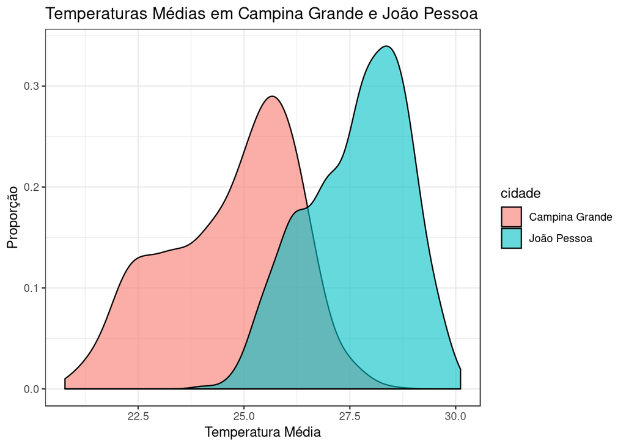

```r
climas %>%
    ggplot(aes(x = tmedia, fill = cidade)) +
    geom_density(alpha = .6) +
    labs(title = "Temperaturas Médias em Campina Grande e João Pessoa", y = "Proporção", x = "Temperatura Média")
```

A visualização nos mostra, que as temperaturas mais altas acontecem mais frequentemente (algumas temperaturas exclusivamente!) em João Pessoa.

### Quais os meses mais quentes e mais frios?

Iremos agora construir boxplots para nos auxiliar a responder esta pergunta. Na visualização a seguir, cada boxplot representa a dispersão dos valores de temperatura média para cada mês do ano.

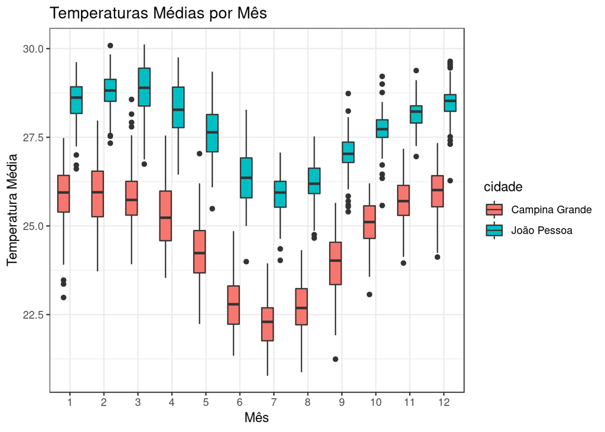

```r
climas <- climas %>%
    mutate(mes = as.factor(month(semana)))


climas %>%
    ggplot(aes(x = mes, y = tmedia)) +
    geom_boxplot(aes(fill = cidade)) +
    labs(title = "Temperaturas Médias por Mês", y = "Temperatura Média", x = "Mês")
```

Portanto, Março parece ser o mês mais quente do ano, enquanto Julho parece ser o mais frio. Também é interessante observar, que esta visualização reforça nossa resposta da primeira pergunta, uma vez que em todos os mêses a temperatura média é maior em João Pessoa.